# Using Yelp review text to predict user rating

Stéphane Nyombayire

November 17, 2015

## Introduction

This project aims at analyzing [Yelp review data set](http://www.yelp.com/dataset_challenge) to understand whether one could infer the rating based on text analysis of the verbatim review text. The rationale behind this study is both an academic exercise on natural language techniques for deriving insights from text, but more importantly this could help Yelp determine the importance of the verbiage provided by the users’ review text to assess whether there is an incremental benefit of having the text for rating a business.

## Methods and Data

The dataset used is located [here](https://www.yelp.com/dataset_challenge/dataset).

Loading data:

```r
rFile = "yelp_academic_dataset_review.json"
dat <- fromJSON(sprintf("[%s]", paste(readLines(rFile), collapse=",")), flatten = TRUE)
```

We used the “yelp_academic_dataset_review.json” file. To read-in the file, we first flatten the data structure into a table for further processing.

```r
str(dat)
```

```
## 'data.frame':    1569264 obs. of  10 variables:
##  $ user_id     : chr  "Xqd0DzHaiyRqVH3WRG7hzg" "H1kH6QZV7Le4zqTRNxoZow" "zvJCcrpm2yOZrxKffwGQLA" "KBLW4wJA_fwoWmMhiHRVOA" ...
##  $ review_id   : chr  "15SdjuK7DmYqUAj6rjGowg" "RF6UnRTtG7tWMcrO2GEoAg" "-TsVN230RCkLYKBeLsuz7A" "dNocEAyUucjT371NNND41Q" ...
##  $ stars       : int  5 2 4 4 4 1 5 5 1 5 ...
##  $ date        : chr  "2007-05-17" "2010-03-22" "2012-02-14" "2012-03-02" ...
##  $ text        : chr  "dr. goldberg offers everything i look for in a general practitioner.  he's nice and easy to talk to without being patronizing; "| __truncated__ "Unfortunately, the frustration of being Dr. Goldberg's patient is a repeat of the experience I've had with so many other doctor"|…
##  $ type        : chr  "review" "review" "review" "review" ...
##  $ business_id : chr  "vcNAWiLM4dR7D2nwwJ7nCA" "vcNAWiLM4dR7D2nwwJ7nCA" "vcNAWiLM4dR7D2nwwJ7nCA" "vcNAWiLM4dR7D2nwwJ7nCA" ...
##  $ votes.funny : int  0 0 0 0 0 0 0 0 0 0 ...
##  $ votes.useful: int  2 2 1 0 2 0 0 0 1 0 ...
##  $ votes.cool  : int  1 0 1 0 1 0 0 0 0 0 ...
```

After that, each text was tokenized into unigrams, and the unigram frequencies were counted and stored into a document-term matrix of counts.This matrix will serve as the base of our modeling and analysis.

```r
matrix <- getDtm(data$text)
```

Code building the matrix is as follow:

```r
getDtm <- function(sentences, language="english",
                         minDocFreq = 1, minWordLength = 4,
                         removeNumbers = TRUE, removePunctuation = TRUE,
                         removeStopwords = TRUE,
                         stemWords = FALSE, stripWhitespace = TRUE,
                         toLower = TRUE, weighting = weightTf) {


  control <- list(language = language, tolower = toLower,
                  removeNumbers = removeNumbers, removePunctuation = removePunctuation,
                  stripWhitespace = stripWhitespace, minWordLength = minWordLength,
                  stopwords = removeStopwords, minDocFreq = minDocFreq,
                  weighting = weighting)

  if (stemWords == TRUE)
    control <- append(control, list(stemming = process.stemwords), after=6)

  content <- apply(as.matrix(sentences), 1, paste, collapse=" ")
  content <- sapply(as.vector(content, mode="character"),
                  iconv, to="UTF8", sub="byte")

  corpus <- Corpus(VectorSource(content), readerControl=list(language=language))
  matrix <- DocumentTermMatrix(corpus,control=control)
  gc() # garbage collect
  return(matrix)
}
```

### Exploratory Analysis and Feature Engineering

#### Frequent Terms Classifier

In order to further understand our data set, let’s look at the most frequently used terms using the matrix produced above:

```r
findFreqTerms(matrix, lowfreq=100)
```

```
##  [1] "also"       "always"     "amazing"    "around"     "back"
##  [6] "bad"        "bar"        "best"       "better"     "came"
## [11] "can"        "cheese"     "chicken"    "come"       "day"
## [16] "definitely" "delicious"  "didnt"      "dinner"     "dont"
## [21] "drinks"     "eat"        "even"       "everything" "experience"
## [26] "first"      "food"       "friendly"   "get"        "give"
## [31] "going"      "good"       "got"        "great"      "ive"
## [36] "just"       "know"       "like"       "little"     "love"
## [41] "made"       "make"       "meal"       "menu"       "much"
## [46] "never"      "nice"       "night"      "now"        "one"
## [51] "order"      "ordered"    "people"     "place"      "pretty"
## [56] "really"     "restaurant" "right"      "say"        "see"
## [61] "service"    "staff"      "sure"       "think"      "time"
## [66] "try"        "two"        "vegas"      "want"       "well"
## [71] "went"       "will"
```

We noticed that there are words such as: best, nice, love, amazing, better, bad, pretty that are widely used and not too surprising given that these are individual reviews of business. This is already a hint at the need to evaluate sentiment for this feedback. We will get to it later.

We can also plot word frequencies (we choose at least 300 mentions):

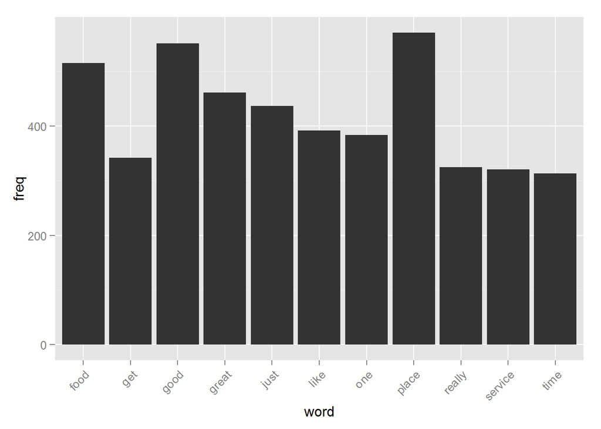

```r
freq <- sort(colSums(as.matrix(matrix)), decreasing=TRUE)
wf <- data.frame(word=names(freq), freq=freq)
ggplot(subset(wf, freq > 300), aes(word, freq)) + geom_bar(stat="identity") + theme(axis.text.x = element_text(angle = 45, hjust = 1))
```

Alternatively, for better visual consumption we can use a word cloud:

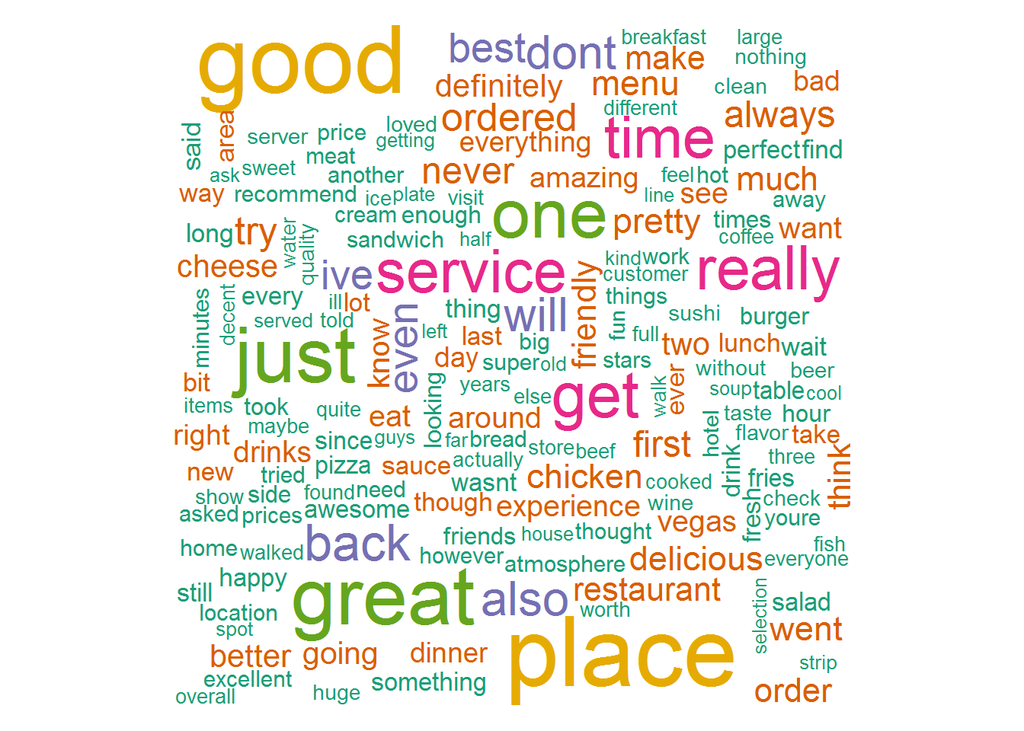

```r
set.seed(123)
wordcloud(names(freq), freq, min.freq = 50, colors = brewer.pal(6, "Dark2"))
```

These terms based on frequency of occurence serve as the basis our initial data set that we will be using for modeling.

### Sentiment Analysis

Our next strategy with feature engineering would be to infer “sentiment” from each word in our matrix. We will score eac word based on the frequency of usage and as reference for positive, neutral and negative we use the following dictionary:

```r
lexicon <- read.csv("subjectivity.csv", head = FALSE, col.names = c('word', 'polarity', 'sentiment'))
str(lexicon)
```

```
## 'data.frame':    6518 obs. of  3 variables:
##  $ word     : Factor w/ 6457 levels "abandon","abandoned",..: 2 3 1 4 5 6 7 8 9 10 ...
##  $ polarity : Factor w/ 2 levels "strongsubj","weaksubj": 2 2 2 1 1 1 2 2 1 1 ...
##  $ sentiment: Factor w/ 4 levels "both","negative",..: 2 2 2 2 2 2 2 2 2 2 ...
```

We will run getSentiment to expand the list of predictors to include the sentiment score as follow:

```r
sentiment = getSentiment(matrix)
data$pScore = as.numeric(sentiment[, 1])
data$nScore = as.numeric(sentiment[, 2])
data$rScore = as.numeric(sentiment[,3])
data$sentiment = sentiment[, 4]
```

Now let’s see how the sentiment analysis performed, if we assume negative to postive rating from 1 through 5

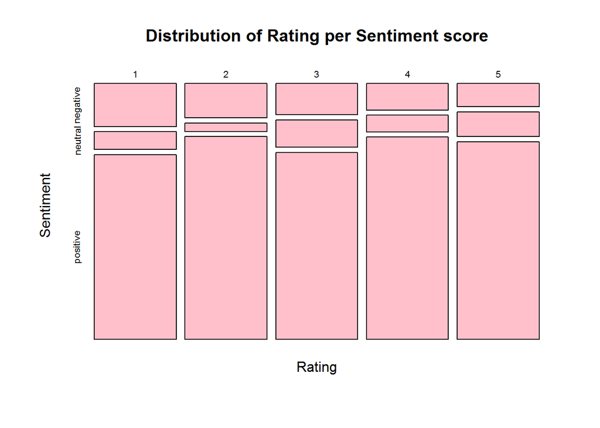

```r
plot(prop.table(table(data$stars, data$sentiment ), 1), main = "Distribution of Rating per Sentiment score", xlab = "Rating", ylab = "Sentiment", color = "pink")
```

### Topic based modeling

To enhance our features for better modeling, in addition to term frequency and sentiment analysis we will also extract the key topics using Latent Dirichlet Allocation (i.e: LDA) using Gibbs method. Now for each word in our document matrix, we will compute the gamma distance to each topic as follow:

```r
lda <- LDA(matrix, method = "Gibbs", control = list(alpha = 0.3), 15)
gammaDF <- as.data.frame(lda@gamma)
names(gammaDF) <- terms(lda)
names(gammaDF)
```

```
##  [1] "chicken"    "bar"        "day"        "coffee"     "store"
##  [6] "pour"       "burger"     "show"       "back"       "restaurant"
## [11] "cream"      "great"      "hotel"      "pizza"      "place"
```

```r
df <- cbind(data, gammaDF)
```

Let’s add the avgRating predictor - we want to examine how average behavior from users perform in our final model, We will also tally up all the votes in another column TotalVotes:

```r
dr = ddply(df,.(user_id),transform,avgRating = mean(stars))
dr$TotalVotes = dr$votes.funny + dr$votes.useful + dr$votes.cool
```

## Results

We will try two models for this classification problem. SVM (support vector machines) and Decision Tree classifier using RPart. First, we split our data sets in training and validation data sets:

```r
d = subset(dr, select = -c(user_id,review_id, date, text, type, business_id))
d$sentiment = as.factor(d$sentiment)
d$stars = as.factor(d$stars)
inTraining = createDataPartition(d$stars, p = .75, list = FALSE)
training = d[ inTraining,]
testing = d[-inTraining,]
```

### SVM

Find below the result from SVM. The model performance is rather poor with accuracy of 38%.

```r
svm.model <- svm(stars ~ ., data = training, cost = 100, gamma = 1, type = "C-classification")
svm.pred <- predict(svm.model, testing[,-1])
confusionMatrix(svm.pred, testing[,1])
```

```
## Confusion Matrix and Statistics
##
##           Reference
## Prediction  1  2  3  4  5
##          1  0  0  0  0  0
##          2  0  0  0  0  0
##          3  0  0  0  0  0
##          4  0  0  5  4  0
##          5 24 21 28 77 89
##
## Overall Statistics
##
##                Accuracy : 0.375
##                  95% CI : (0.3146, 0.4385)
##     No Information Rate : 0.3589
##     P-Value [Acc > NIR] : 0.3199
##
##                   Kappa : 0.0269
##  Mcnemar's Test P-Value : NA
##
## Statistics by Class:
##
##                      Class: 1 Class: 2 Class: 3 Class: 4 Class: 5
## Sensitivity           0.00000  0.00000   0.0000  0.04938   1.0000
## Specificity           1.00000  1.00000   1.0000  0.97006   0.0566
## Pos Pred Value            NaN      NaN      NaN  0.44444   0.3724
## Neg Pred Value        0.90323  0.91532   0.8669  0.67782   1.0000
## Prevalence            0.09677  0.08468   0.1331  0.32661   0.3589
## Detection Rate        0.00000  0.00000   0.0000  0.01613   0.3589
## Detection Prevalence  0.00000  0.00000   0.0000  0.03629   0.9637
## Balanced Accuracy     0.50000  0.50000   0.5000  0.50972   0.5283
```

### RPart

Decision tree model performs alot better acheiving 97% accuracy with very good recall and specificity as well. Kappa is also pretty high.

```r
rpart.model = rpart(stars ~ ., data= training )
rpart.pred = predict(rpart.model, testing[, -1], type = "class")
confusionMatrix(rpart.pred, testing[,1])
```

```
## Confusion Matrix and Statistics
##
##           Reference
## Prediction  1  2  3  4  5
##          1 23  0  0  0  0
##          2  0 20  0  0  0
##          3  1  1 32  1  0
##          4  0  0  1 80  1
##          5  0  0  0  0 88
##
## Overall Statistics
##
##                Accuracy : 0.9798
##                  95% CI : (0.9536, 0.9934)
##     No Information Rate : 0.3589
##     P-Value [Acc > NIR] : < 2.2e-16
##
##                   Kappa : 0.9724
##  Mcnemar's Test P-Value : NA
##
## Statistics by Class:
##
##                      Class: 1 Class: 2 Class: 3 Class: 4 Class: 5
## Sensitivity           0.95833  0.95238   0.9697   0.9877   0.9888
## Specificity           1.00000  1.00000   0.9860   0.9880   1.0000
## Pos Pred Value        1.00000  1.00000   0.9143   0.9756   1.0000
## Neg Pred Value        0.99556  0.99561   0.9953   0.9940   0.9938
## Prevalence            0.09677  0.08468   0.1331   0.3266   0.3589
## Detection Rate        0.09274  0.08065   0.1290   0.3226   0.3548
## Detection Prevalence  0.09274  0.08065   0.1411   0.3306   0.3548
## Balanced Accuracy     0.97917  0.97619   0.9779   0.9878   0.9944
```

## Discussion

Only AvgRating:

```r
rpart.model = rpart(stars ~ ., data= subset(training, select = c(stars, avgRating)))
rpart.pred = predict(rpart.model, testing[, -1], type = "class")
confusionMatrix(rpart.pred, testing[,1])["overall"]
```

```
## $overall
##       Accuracy          Kappa  AccuracyLower  AccuracyUpper   AccuracyNull
##   9.798387e-01   9.723849e-01   9.535800e-01   9.934221e-01   3.588710e-01
## AccuracyPValue  McnemarPValue
##  5.823676e-100            NaN
```

No AvgRating:

```r
rpart.model = rpart(stars ~ ., data= subset(training, select = -c(avgRating)))
rpart.pred = predict(rpart.model, testing[, -1], type = "class")
confusionMatrix(rpart.pred, testing[,1])["overall"]
```

```
## $overall
##       Accuracy          Kappa  AccuracyLower  AccuracyUpper   AccuracyNull
##      0.3427419      0.0023692      0.2838543      0.4054405      0.3588710
## AccuracyPValue  McnemarPValue
##      0.7229272            NaN
```